# BDA523 Assignment 2 - data Income Prediction

Feray Ece Topcu

May 04, 2018

```r
library(ggplot2)
library(dplyr)
library(tidyr)
```

## Exploratory Data Analysis and Data Cleaning

- Read Data

```r
data <-read.csv("C:/Users/ecetp/Downloads/MEF/BDA 523 - Marketing Analytics/Assignments/Assignment2/adult.csv")
summary(data)
```

```
##       age                   workclass         fnlwgt
##  Min.   :17.00   Private         :33906   Min.   :  12285
##  1st Qu.:28.00   Self-emp-not-inc: 3862   1st Qu.: 117551
##  Median :37.00   Local-gov       : 3136   Median : 178145
##  Mean   :38.64   ?               : 2799   Mean   : 189664
##  3rd Qu.:48.00   State-gov       : 1981   3rd Qu.: 237642
##  Max.   :90.00   Self-emp-inc    : 1695   Max.   :1490400
##                  (Other)         : 1463
##         education     educational.num               marital.status
##  HS-grad     :15784   Min.   : 1.00   Divorced             : 6633
##  Some-college:10878   1st Qu.: 9.00   Married-AF-spouse    :   37
##  Bachelors   : 8025   Median :10.00   Married-civ-spouse   :22379
##  Masters     : 2657   Mean   :10.08   Married-spouse-absent:  628
##  Assoc-voc   : 2061   3rd Qu.:12.00   Never-married        :16117
##  11th        : 1812   Max.   :16.00   Separated            : 1530
##  (Other)     : 7625                   Widowed              : 1518
##            occupation            relationship                   race
##  Prof-specialty : 6172   Husband       :19716   Amer-Indian-Eskimo:  470
##  Craft-repair   : 6112   Not-in-family :12583   Asian-Pac-Islander: 1519
##  Exec-managerial: 6086   Other-relative: 1506   Black             : 4685
##  Adm-clerical   : 5611   Own-child     : 7581   Other             :  406
##  Sales          : 5504   Unmarried     : 5125   White             :41762
##  Other-service  : 4923   Wife          : 2331
##  (Other)        :14434
##     gender       capital.gain    capital.loss    hours.per.week
##  Female:16192   Min.   :    0   Min.   :   0.0   Min.   : 1.00
##  Male  :32650   1st Qu.:    0   1st Qu.:   0.0   1st Qu.:40.00
##                 Median :    0   Median :   0.0   Median :40.00
##                 Mean   : 1079   Mean   :  87.5   Mean   :40.42
##                 3rd Qu.:    0   3rd Qu.:   0.0   3rd Qu.:45.00
##                 Max.   :99999   Max.   :4356.0   Max.   :99.00
##
##        native.country    income
##  United-States:43832   <=50K:37155
##  Mexico       :  951   >50K :11687
##  ?            :  857
##  Philippines  :  295
##  Germany      :  206
##  Puerto-Rico  :  184
##  (Other)      : 2517
```

```r
#str(data)
#head(data)

#workclass includes "?""
#capital.gain
#capital loss
#native country includes "?"
#occupation ?
```

- Delete “?” rows because they are useless:

```r
#dirty_data <- data %>% filter(workclass=="?")
data <- data  %>% filter(workclass!="?")
data <- data  %>% filter(occupation!="?")
data <- data  %>% filter(native.country!="?")

summary(data)
```

```
##       age                   workclass         fnlwgt
##  Min.   :17.00   Private         :33307   Min.   :  13492
##  1st Qu.:28.00   Self-emp-not-inc: 3796   1st Qu.: 117388
##  Median :37.00   Local-gov       : 3100   Median : 178316
##  Mean   :38.55   State-gov       : 1946   Mean   : 189735
##  3rd Qu.:47.00   Self-emp-inc    : 1646   3rd Qu.: 237926
##  Max.   :90.00   Federal-gov     : 1406   Max.   :1490400
##                  (Other)         :   21
##         education     educational.num               marital.status
##  HS-grad     :14783   Min.   : 1.00   Divorced             : 6297
##  Some-college: 9899   1st Qu.: 9.00   Married-AF-spouse    :   32
##  Bachelors   : 7570   Median :10.00   Married-civ-spouse   :21055
##  Masters     : 2514   Mean   :10.12   Married-spouse-absent:  552
##  Assoc-voc   : 1959   3rd Qu.:13.00   Never-married        :14598
##  11th        : 1619   Max.   :16.00   Separated            : 1411
##  (Other)     : 6878                   Widowed              : 1277
##            occupation            relationship                   race
##  Craft-repair   : 6020   Husband       :18666   Amer-Indian-Eskimo:  435
##  Prof-specialty : 6008   Not-in-family :11702   Asian-Pac-Islander: 1303
##  Exec-managerial: 5984   Other-relative: 1349   Black             : 4228
##  Adm-clerical   : 5540   Own-child     : 6626   Other             :  353
##  Sales          : 5408   Unmarried     : 4788   White             :38903
##  Other-service  : 4808   Wife          : 2091
##  (Other)        :11454
##     gender       capital.gain    capital.loss     hours.per.week
##  Female:14695   Min.   :    0   Min.   :   0.00   Min.   : 1.00
##  Male  :30527   1st Qu.:    0   1st Qu.:   0.00   1st Qu.:40.00
##                 Median :    0   Median :   0.00   Median :40.00
##                 Mean   : 1101   Mean   :  88.59   Mean   :40.94
##                 3rd Qu.:    0   3rd Qu.:   0.00   3rd Qu.:45.00
##                 Max.   :99999   Max.   :4356.00   Max.   :99.00
##
##        native.country    income
##  United-States:41292   <=50K:34014
##  Mexico       :  903   >50K :11208
##  Philippines  :  283
##  Germany      :  193
##  Puerto-Rico  :  175
##  Canada       :  163
##  (Other)      : 2213
```

- Some of the variables are not self-explanatory. The continuous variable fnlwgt represents final weight, which is the number of units in the target population that the responding unit represents. The variable education_num stands for the number of years of education in total, which is a continuous representation of the discrete variable education. The variable relationship represents the responding unit’s role in the family. capital_gain and capital_loss are income from investment sources other than wage/salary.

For simplicity of this analysis, the weighting factor is discarded. Total number of years of education can represent by the highest education level completed. Role in the family can be assessed from gender and marital status. Thus, the following 3 variables are deleted education, relationship, and fnlwgt.

- Discard these columns:

```r
data$fnlwgt <-NULL
data$education <- NULL
data$relationship <- NULL


data$capital.gain <- NULL
data$capital.loss <- NULL
data$native.country <- NULL
```

- Histogram of age distribution due to income group:

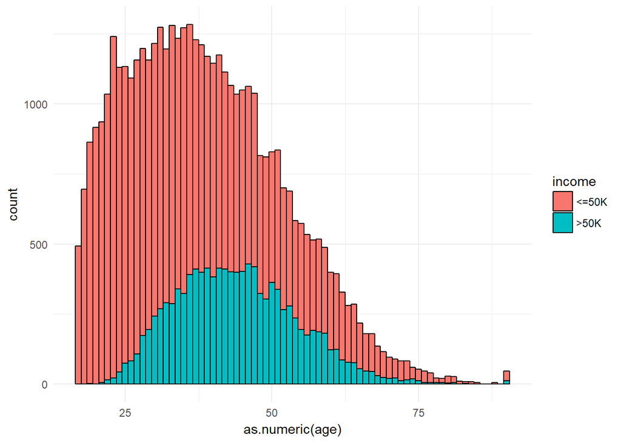

```r
# age vs income group
ggplot(data) + aes(x=as.numeric(age), group=income, fill=income) +
  geom_histogram(binwidth=1, color='black') + theme_minimal()
```

- Histogram of age distribution due to gender:

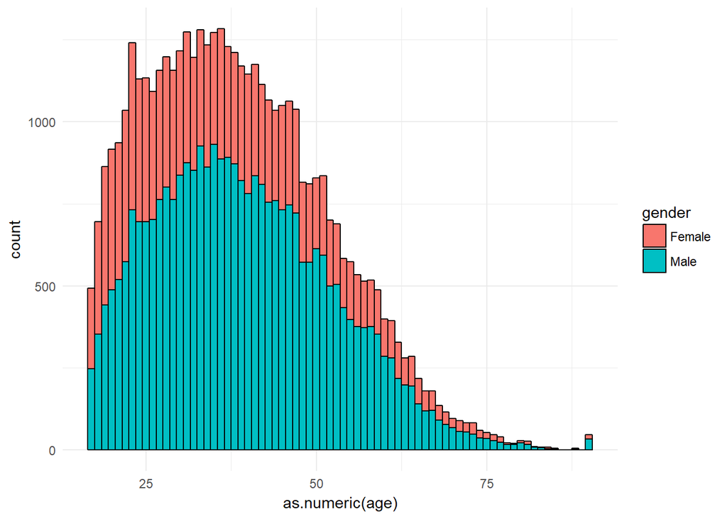

```r
#  age vs gender group
ggplot(data) + aes(x=as.numeric(age), group=gender, fill=gender) +
  geom_histogram(binwidth=1, color='black') + theme_minimal()
```

- **Clean workclass column:** As we can see of summary; there are some dummy rows in this column. So, I’ve decided to combine Never-Worked and Without-pay rows and reclassify other work-classes to decrease the categories. After reclassifying; there should be 4 different category on workclass column.

```r
#summary of column:
summary(data$workclass)
```

```
##                ?      Federal-gov        Local-gov     Never-worked
##                0             1406             3100                0
##          Private     Self-emp-inc Self-emp-not-inc        State-gov
##            33307             1646             3796             1946
##      Without-pay
##               21
```

```r
# combine into Government job
data$workclass <- gsub('^Federal-gov', 'Government', data$workclass)
data$workclass <- gsub('^Local-gov', 'Government', data$workclass)
data$workclass <- gsub('^State-gov', 'Government', data$workclass)

# combine into Sele-Employed job
data$workclass <- gsub('^Self-emp-inc', 'Self-Employed', data$workclass)
data$workclass <- gsub('^Self-emp-not-inc', 'Self-Employed', data$workclass)

# combine into Other/Unknown
data$workclass <- gsub('^Never-worked', 'Other', data$workclass)
data$workclass <- gsub('^Without-pay', 'Other', data$workclass)
data$workclass <- gsub('^Other', 'Other/Unknown', data$workclass)
data$workclass <- gsub('^Unknown', 'Other/Unknown', data$workclass)


data$workclass <- as.factor(data$workclass)

#summary again:
summary(data$workclass)
```

```
##    Government Other/Unknown       Private Self-Employed
##          6452            21         33307          5442
```

- Examine the relationship between industry and income:

```r
ind_income <- data %>%
              group_by(workclass,income) %>%
              summarise(Count = n(),Perc=round(n()/nrow(.)*100,2)) %>%
              arrange(desc(workclass,income))
ind_income
```

```
## # A tibble: 8 x 4
## # Groups: workclass [4]
##   workclass     income Count    Perc
##   <fctr>        <fctr> <int>   <dbl>
## 1 Self-Employed <=50K   3471  7.68
## 2 Self-Employed >50K    1971  4.36
## 3 Private       <=50K  26056 57.6
## 4 Private       >50K    7251 16.0
## 5 Other/Unknown <=50K     19  0.0400
## 6 Other/Unknown >50K       2  0
## 7 Government    <=50K   4468  9.88
## 8 Government    >50K    1984  4.39
```

```r
#ggplot(ind_income, aes(x = workclass, y = Count, fill = income)) +
#  geom_bar(stat = "identity") +
#  ggtitle('Income by Industry')  + theme_minimal()
```

- Since **education_num** is a continuous representation of **education** which we deleted on first step:

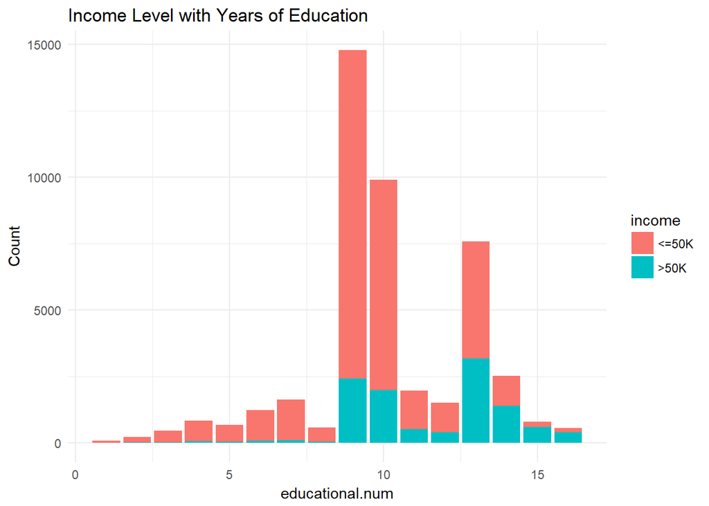

```r
edu_income <- data %>%
              group_by(educational.num,income) %>%
              summarise(Count = n(),Perc=round(n()/nrow(.)*100,2)) %>%
              arrange(desc(educational.num,income))
#edu_income

ggplot(edu_income, aes(x = educational.num, y = Count, fill = income)) +
  geom_bar(stat = "identity") +
  #geom_text(aes(x= Perc, label=format(Perc, digits=2)), size = 2) +
  ggtitle('Income Level with Years of Education') +theme_minimal()
```

- Clean occupation column:

```r
levels(data$occupation)[1] <- 'Unknown'

data$occupation <- gsub('Adm-clerical', 'White-Collar', data$occupation)
data$occupation <- gsub('Craft-repair', 'Blue-Collar', data$occupation)
data$occupation <- gsub('Exec-managerial', 'White-Collar', data$occupation)
data$occupation <- gsub('Farming-fishing', 'Blue-Collar', data$occupation)
data$occupation <- gsub('Handlers-cleaners', 'Blue-Collar', data$occupation)
data$occupation <- gsub('Machine-op-inspct', 'Blue-Collar', data$occupation)
data$occupation <- gsub('Other-service', 'Service', data$occupation)
data$occupation <- gsub('Priv-house-serv', 'Service', data$occupation)
data$occupation <- gsub('Prof-specialty', 'Professional', data$occupation)
data$occupation <- gsub('Protective-serv', 'Service', data$occupation)
data$occupation <- gsub('Tech-support', 'Service', data$occupation)
data$occupation <- gsub('Transport-moving', 'Blue-Collar', data$occupation)
data$occupation <- gsub('Unknown', 'Other/Unknown', data$occupation)
data$occupation <- gsub('Armed-Forces', 'Other/Unknown', data$occupation)
data$occupation <- as.factor(data$occupation)

summary(data$occupation)
```

```
##   Blue-Collar Other/Unknown  Professional         Sales       Service
##         14832            14          6008          5408          7436
##  White-Collar
##         11524
```

```r
data$marital.status <- gsub('Married-AF-spouse', 'Married', data$marital.status)
data$marital.status <- gsub('Married-civ-spouse', 'Married', data$marital.status)
data$marital.status <- gsub('Married-spouse-absent', 'Married', data$marital.status)
data$marital.status <- gsub('Never-married', 'Single', data$marital.status)
data$marital.status <- as.factor(data$marital.status)

summary(data$marital.status)
```

```
##  Divorced   Married Separated    Single   Widowed
##      6297     21639      1411     14598      1277
```

```r
glimpse(data)
```

```
## Observations: 45,222
## Variables: 9
## $ age             <int> 25, 38, 28, 44, 34, 63, 24, 55, 65, 36, 26, 48...
## $ workclass       <fctr> Private, Private, Government, Private, Privat...
## $ educational.num <int> 7, 9, 12, 10, 6, 15, 10, 4, 9, 13, 9, 9, 14, 1...
## $ marital.status  <fctr> Single, Married, Married, Married, Single, Ma...
## $ occupation      <fctr> Blue-Collar, Blue-Collar, Service, Blue-Colla...
## $ race            <fctr> Black, White, White, Black, White, White, Whi...
## $ gender          <fctr> Male, Male, Male, Male, Male, Male, Female, M...
## $ hours.per.week  <int> 40, 50, 40, 40, 30, 32, 40, 10, 40, 40, 39, 48...
## $ income          <fctr> <=50K, <=50K, >50K, >50K, <=50K, >50K, <=50K,...
```

- Now we have clean data with 9 different columns. So, we can start modelling.

## Logistic Regression

- Splite data as train and test dataset. (80%-%20)

```r
sz <- round(.8 * dim(data)[1])  # training set size
training_set <- data[1:sz,]
testing_set <- data[-(1:sz),]
```

- Fit Logistic Regression to training dataset. Calculate Anova.

```r
adult_fit <- glm(income ~ ., data = training_set, family = binomial)
summary(adult_fit)
```

```
##
## Call:
## glm(formula = income ~ ., family = binomial, data = training_set)
##
## Deviance Residuals:
##     Min       1Q   Median       3Q      Max
## -2.7201  -0.6009  -0.2645  -0.0652   3.2840
##
## Coefficients:
##                          Estimate Std. Error z value Pr(>|z|)
## (Intercept)             -9.317770   0.229405 -40.617  < 2e-16 ***
## age                      0.028467   0.001389  20.496  < 2e-16 ***
## workclassOther/Unknown  -0.463898   0.871555  -0.532 0.594543
## workclassPrivate         0.056520   0.044207   1.279 0.201062
## workclassSelf-Employed  -0.209009   0.056807  -3.679 0.000234 ***
## educational.num          0.317639   0.007986  39.773  < 2e-16 ***
## marital.statusMarried    2.082742   0.056799  36.669  < 2e-16 ***
## marital.statusSeparated  0.020113   0.133432   0.151 0.880182
## marital.statusSingle    -0.429347   0.069634  -6.166 7.02e-10 ***
## marital.statusWidowed   -0.015834   0.128813  -0.123 0.902169
## occupationOther/Unknown  0.685260   0.891795   0.768 0.442246
## occupationProfessional   0.782654   0.056136  13.942  < 2e-16 ***
## occupationSales          0.460864   0.052317   8.809  < 2e-16 ***
## occupationService        0.131169   0.055421   2.367 0.017943 *
## occupationWhite-Collar   0.798661   0.043515  18.354  < 2e-16 ***
## raceAsian-Pac-Islander   0.153169   0.203894   0.751 0.452520
## raceBlack                0.207412   0.193131   1.074 0.282846
## raceOther                0.114007   0.281952   0.404 0.685956
## raceWhite                0.454395   0.183974   2.470 0.013516 *
## genderMale               0.377412   0.043444   8.687  < 2e-16 ***
## hours.per.week           0.030359   0.001382  21.971  < 2e-16 ***
## ---
## Signif. codes:  0 '***' 0.001 '**' 0.01 '*' 0.05 '.' 0.1 ' ' 1
##
## (Dispersion parameter for binomial family taken to be 1)
##
##     Null deviance: 40379  on 36177  degrees of freedom
## Residual deviance: 27078  on 36157  degrees of freedom
## AIC: 27120
##
## Number of Fisher Scoring iterations: 6
```

```r
print(anova(adult_fit, test="Chisq"))
```

```
## Analysis of Deviance Table
##
## Model: binomial, link: logit
##
## Response: income
##
## Terms added sequentially (first to last)
##
##
##                 Df Deviance Resid. Df Resid. Dev  Pr(>Chi)
## NULL                            36177      40379
## age              1   1908.4     36176      38471 < 2.2e-16 ***
## workclass        3    187.6     36173      38283 < 2.2e-16 ***
## educational.num  1   4124.0     36172      34159 < 2.2e-16 ***
## marital.status   4   6026.4     36168      28133 < 2.2e-16 ***
## occupation       5    351.0     36163      27781 < 2.2e-16 ***
## race             4     49.7     36159      27732 4.108e-10 ***
## gender           1    157.8     36158      27574 < 2.2e-16 ***
## hours.per.week   1    495.4     36157      27078 < 2.2e-16 ***
## ---
## Signif. codes:  0 '***' 0.001 '**' 0.01 '*' 0.05 '.' 0.1 ' ' 1
```

- Test and confusion matrix:

```r
prob <- predict(adult_fit, testing_set, type = 'response')   #responses
pred <- rep('<=50K', length(prob))
pred[prob>=.5] <- '>50K'

# confusion matrix
print("Confusion Matrix:\n")
```

```
## [1] "Confusion Matrix:\n"
```

```r
confusion_matrix <- table(pred, testing_set$income)
confusion_matrix
```

```
##
## pred    <=50K >50K
##   <=50K  6219 1066
##   >50K    522 1237
```

```r
predictive_accuracy <- (confusion_matrix[1,1] + confusion_matrix[2,2])/
                        sum(confusion_matrix)
cat("\nPercent Accuracy: ", round(predictive_accuracy * 100, digits = 1))
```

```
##
## Percent Accuracy:  82.4
```

- Calculate lift and 10 Decile for logistic model:

```r
baseline_response_rate <-
    as.numeric(table(testing_set$income)[2])/nrow(data)

#baseline_response_rate

lift <- function(x, baseline_response_rate) {
    mean(x) / baseline_response_rate
}

cat("lift: ",lift(prob,baseline_response_rate))
```

```
## lift:  4.904822
```

```r
#decile:
decile_break_points <- c(as.numeric(quantile(prob,probs=seq(0, 1, 0.10))))

decile_break_points
```

```
##  [1] 0.0004630211 0.0128935770 0.0245340759 0.0437267074 0.0778396395
##  [6] 0.1415252959 0.2352521292 0.3355571597 0.4880691003 0.7036618680
## [11] 0.9716991351
```

```r
#length(decile_break_points)

#prob

# data$decile <- cut(as.numeric(prob),
#     breaks = decile_break_points,
#     include.lowest=TRUE,
#     labels=c("Decile_10","Decile_9","Decile_8","Decile_7","Decile_6",
#     "Decile_5","Decile_4","Decile_3","Decile_2","Decile_1"))
#
# decile

#cat("\nDecile: ",decile)
```

### References

- [Logistic Regression](https://infocenter.informationbuilders.com/wf80/index.jsp?topic=%2Fpubdocs%2FRStat16%2Fsource%2Ftopic43.htm)
- [Basic Logistic Regression with R](http://r-statistics.co/Logistic-Regression-With-R.html)
- [Simple Logistic Regression](https://www.analyticsvidhya.com/blog/2015/11/beginners-guide-on-logistic-regression-in-r/)
- [Decile Analysis](http://www.rapidinsightinc.com/how-to-interpret-a-decile-analysis/)